# 1. Simulate two datasets, 1000 observations each. Create the first dataset in a way to pass all diagnostic plots (so, all assumptions are valid). Create the second dataset in order to fail with at lea

### 3. Choose three tests for model diagnostic

- Durbin-Watson test for autocorrelation of disturbances.
- Rainbow test for linearity.
- Ramsey's RESET test for functional form.

### 4. For each test create two simulated datasets. One that passes the given test and one that does not (e.g. simulate data with heterogeneous variance).

As an ideal dataset, which has lack of first order autocorrelation in epsilons, model coefficients are the same for high/low values of \( x \) and relation between \( x \) and \( y \) is linear, we will use dataset1 from the first exercise.

Dataset3 – first order autocorrelation in epsilons:

```r
set.seed(7)

X3 <- sort(X1)
Y3 <- 3.14*X3 + arima.sim(n = 1000, list(ar = 0.5), sd = 15)
dataset3 <- data.frame(X3,Y3)
```

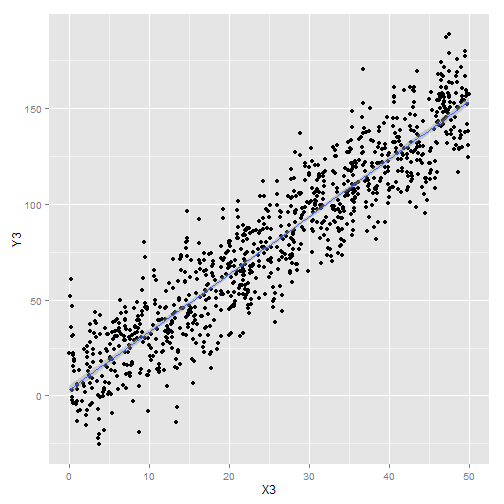

```r
library("ggplot2")
ggplot(dataset3, aes(x=X3, y=Y3)) +
  geom_point() + geom_smooth(method="lm", formula=y~x)
```

Dataset4 – model coefficients are different for high/low values of \( x \):

```r
set.seed(7)

X4 <- X1
Y4 <- rep(0, times=1000)
Y4[X4<25] <- 0.785*X4[X4<25]
Y4[X4>=25] <- 6.28*X4[X4>=25]
Y4 <- Y4 +  rnorm(1000, mean = 0, sd = 15)
dataset4 <- data.frame(X4, Y4)
```

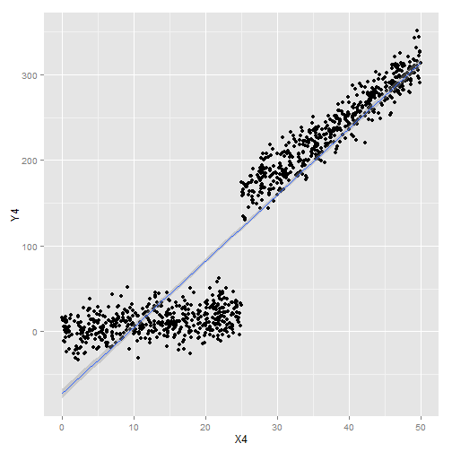

```r
library("ggplot2")
ggplot(dataset4, aes(x=X4, y=Y4)) +
  geom_point() + geom_smooth(method="lm", formula=y~x)
```

Dataset5 – relation between \( x \) and \( y \) is not linear:

```r
set.seed(7)

X5 <- X1
Y5 <- 0.785* X5^2 + 3.14*X5 + rnorm(1000, mean = 0, sd = 50)
dataset5 <- data.frame(X5, Y5)
```

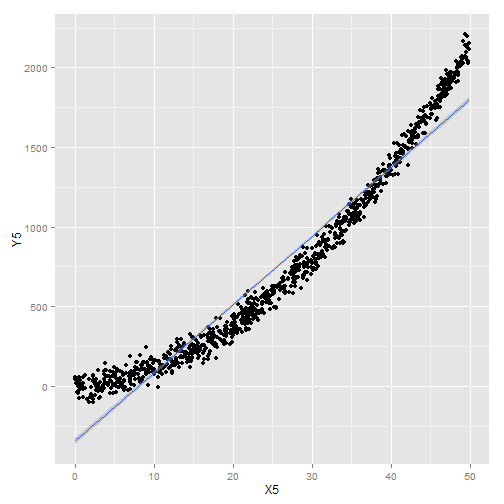

```r
library("ggplot2")
ggplot(dataset5, aes(x=X5, y=Y5)) +
  geom_point() + geom_smooth(method="lm", formula=y~x)
```

### 5. Present results from diagnostic tests, show p-values for both datasets.

```r
library("lmtest")
```

Durbin-Watson test for autocorrelation of disturbances.

```r
dwtest( Y1 ~ X1, order.by=~X1, data = dataset1)
```

```
##
##  Durbin-Watson test
##
## data:  Y1 ~ X1
## DW = 2.0059, p-value = 0.5248
## alternative hypothesis: true autocorrelation is greater than 0
```

```r
dwtest( Y3 ~ X3, order.by=~X3, data = dataset3)
```

```
##
##  Durbin-Watson test
##
## data:  Y3 ~ X3
## DW = 0.9524, p-value < 2.2e-16
## alternative hypothesis: true autocorrelation is greater than 0
```

Rainbow test for linearity.

```r
raintest( Y1 ~ X1, order.by=~X1, data = dataset1)
```

```
##
##  Rainbow test
##
## data:  Y1 ~ X1
## Rain = 0.9713, df1 = 500, df2 = 498, p-value = 0.6273
```

```r
raintest( Y4 ~ X4, order.by=~X4, data = dataset4)
```

```
##
##  Rainbow test
##
## data:  Y4 ~ X4
## Rain = 1.5557, df1 = 500, df2 = 498, p-value = 4.483e-07
```

Ramsey's RESET test for functional form.

```r
resettest( Y1 ~ X1, data = dataset1, type="regressor")
```

```
##
##  RESET test
##
## data:  Y1 ~ X1
## RESET = 0.6095, df1 = 2, df2 = 996, p-value = 0.5438
```

```r
resettest( Y5 ~ X5, data = dataset5, type="regressor")
```

```
##
##  RESET test
##
## data:  Y5 ~ X5
## RESET = 4457.861, df1 = 2, df2 = 996, p-value < 2.2e-16
```

As we expected - dataset1 passes all given tests, while datasets 3, 4, 5 fail the corresponding tests.